# Quant_Group_7

E.Sheild_N.Levine_G.Barrett-Jackson

11/18/21

# Research Question

What is the relationship between the installation of bicycle facilities and gentrification in the City of Los Angeles?

# Prior Research

## Current News Articles

Our group also sought to explore current news articles related to this research area. They can be found in the bibliography.

# Data

The sample population for this study is the all census tracts in the City of Los Angeles. The analysis will include the following categorical and continuous variables:

## Categorical Variables

- Tenure: 2019 American Communities Survey (ACS) “Did this person live in this house or apartment 5 years ago?”
- Race (White): 2019 American Communities Survey (ACS) “What is Person 1’s race?”

ACS Defines “White. A person having origins in any of the original peoples of Europe, the Middle East, or North Africa. It includes people who indicate their race as”White" or report entries such as Irish, German, Italian, Lebanese, Arab, Moroccan, or Caucasian."

The number of individuals identifying as white alone is initially a continuous variable, so we created a new column in our data for the total population within that census tract and converted each figure into a percentage. The average white alone population in the City of LA is 52.1%, so we then categorized the data into tracts with over 52.1% white (labeled as white) and tracts under 52.1% white (labeled as non-white). The categorical variable is now defined as binary_white.

## Continious Variables

- Median Income: 2019 American Communities Survey (ACS) “What was this person’s total income during the past 12 months?”
- Means of Transportation (Bike): 2019 American Communities Survey (ACS) “How did this person usually get to work last week?”
- Median Age: 2019 American Communities Survey (ACS)
- Bikeways (Feet): LA City GeoHub*

*Includes Lane (69.98%), Protected Bike Lane (2.38%), Buffer Bike Lane (1.08%), and Path (0.75%. Excludes Sharrowed Route (14.48%), Route (11.04%), Bicycle Friendly Street (0.17%), Temp Removal Sharrowed Route (0.08%), and Detour Sharrowed Route (0.03%).

# Load Data

```r
library(tidyverse)
library(tigris)
library(tidycensus)
library(readxl)
library(knitr)
library(sf)
library(tidyverse)
library(ggthemes)
library(units)
library(nngeo)
library(osmextract)
library(tidygeocoder)
library(tmap)
library(rmapshaper)
library(zonebuilder)
library(ggspatial)
library(dplyr)
library(gridExtra)
library(jtools)
library(huxtable)
```

```r
dir.create("networks")

LA_file <- oe_match("Los Angeles")
```

```r
city_boundary <- st_read("networks/City_Boundary.geojson")
```

```r
CA5_state_plane <- "+proj=lcc +lat_1=34.03333333333333 +lat_2=35.46666666666667 +lat_0=33.5 +lon_0=-118 +x_0=2000000 +y_0=500000 +ellps=GRS80 +units=m +no_defs"

la_city_limits <- places("California") %>%
   filter(NAME == "Los Angeles") %>%
   st_transform(crs = st_crs(city_boundary))

city_boundary <- city_boundary[la_city_limits,]
```

The below data is considered joined because we sourced it all at the same geography from the same source. There was no need to join the data, but the data did produce 1001 observations of 17 variables.

```r
acs_all <- get_acs(geography = "tract", year = 2019, state = "CA", county = "Los Angeles", variables = c(white_ = "B02001_002", med_income_ = "B21004_001", res_new_ = "B07001_049", transport_ = "B08301_018", pop_ = "B01003_001", med_age_ = "B01002_001"), output = "wide", geometry = TRUE)

pl <- places(state = "CA", cb = TRUE)

la.city <- filter(pl, NAME == "Los Angeles")

acs_la_tracts <- ms_clip(target = acs_all, clip = la.city, remove_slivers = TRUE)
```

Percent white

```r
acs_la_tracts_new <- acs_la_tracts
acs_la_tracts_new$percent_white <- acs_la_tracts$white_E/acs_la_tracts$pop_E
acs_la_tracts_new
```

```r
acs_la_tracts_new$binary_white <- ifelse(acs_la_tracts_new$percent_white > 0.521, "white", "non_white")
```

Bikeways

```r
bikeways <- st_read("networks/census_tracts_including_bikeways2/census_tracts_LA_city_2020_SummarizeWithin.shp")
bikeways$CT20 <- paste("06037", bikeways$CT20, sep = "", collapse = NULL)
bikeways <- rename(bikeways, GEOID = CT20)
```

Percent of new residents

```r
acs_la_tracts_new2 <- acs_la_tracts_new
acs_la_tracts_new2$percent_res_new <- acs_la_tracts_new$res_new_E/acs_la_tracts$pop_E
acs_la_tracts_new2
```

```r
bikeways2 <- inner_join(bikeways %>% as.data.frame(), acs_la_tracts_new2 %>% as.data.frame(), by = "GEOID")
```

```r
tract_areas <- tracts(state = "CA", county = "Los Angeles") %>%
     st_drop_geometry() %>%
     select(GEOID, ALAND) %>%
     mutate(area_sq_miles = ALAND / 2589988.11)
bikeways3 <- inner_join(bikeways2 %>% as.data.frame(), tract_areas %>% as.data.frame(), by = "GEOID")
```

```r
bikeways3$pop_density <- bikeways3$pop_E / bikeways3$area_sq_miles
```

```r
bikeways3$percent_bike <- bikeways3$transport_E / bikeways3$pop_E
```

# Descriptive Statistics

## Continuous Variables

The continuous variables our group used are median income, mode of transportation to work, and median age.

Calculations

```r
inc_t_test <- t.test(acs_la_tracts_new$med_income_E)
transport_t_test <- t.test(acs_la_tracts_new$transport_E)
age_t_test <-t.test(acs_la_tracts_new$med_age_E)
bikeways_t_test <- t.test(bikeways2$sum_Length)
```

### Median and interquartile range

```r
inc_quartiles <- quantile(acs_la_tracts_new$med_income_E, na.rm = TRUE)
transport_quartiles <- quantile(acs_la_tracts_new$transport_E, na.rm = TRUE)
age_quartiles <- quantile(acs_la_tracts_new$med_age_E, na.rm = TRUE)
bikeways_quartiles <- quantile(bikeways2$sum_Length, na.rm = TRUE)
```

### Get standard deviation

```r
inc_st_dev <- sd(acs_la_tracts_new$med_income_E, na.rm = TRUE)
transport_st_dev <- sd(acs_la_tracts_new$transport_E, na.rm = TRUE)
age_st_dev <- sd(acs_la_tracts_new$med_age_E, na.rm = TRUE)
bikeways_st_dev <- sd(bikeways2$sum_Length, na.rm = TRUE)
```

### Displaying a histogram

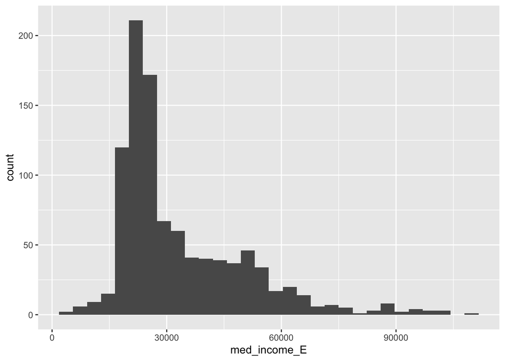

```r
inc_hist <- ggplot(acs_la_tracts_new) +
  geom_histogram(aes(x = med_income_E),
                 bins = 30)

transport_hist <- ggplot(acs_la_tracts_new) +
  geom_histogram(aes(x = transport_E),
                 bins = 30)

age_hist <- ggplot(acs_la_tracts_new) +
  geom_histogram(aes(x = med_age_E),
                 bins = 30)

bikeways_hist <- ggplot(bikeways2) +
  geom_histogram(aes(x = sum_Length),
                 bins = 30)

inc_hist
```

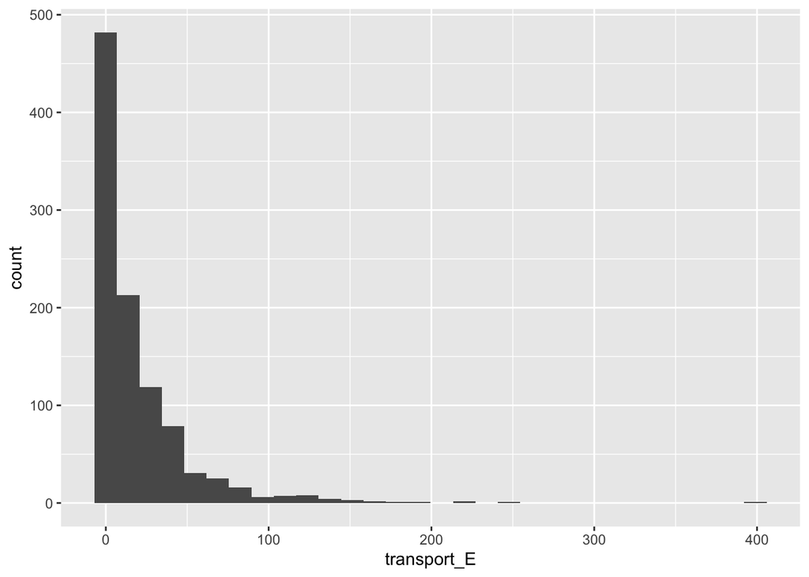

```r
transport_hist
```

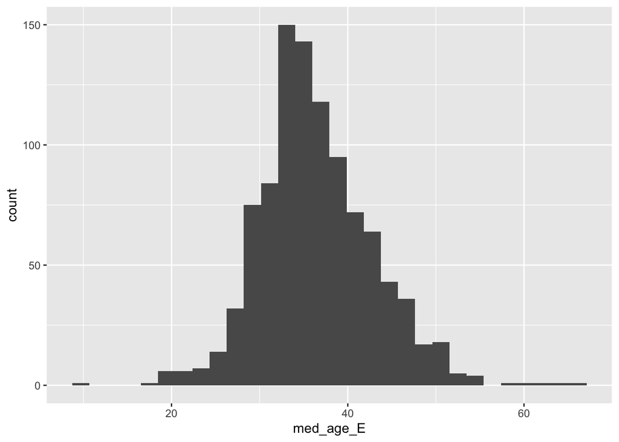

```r
age_hist
```

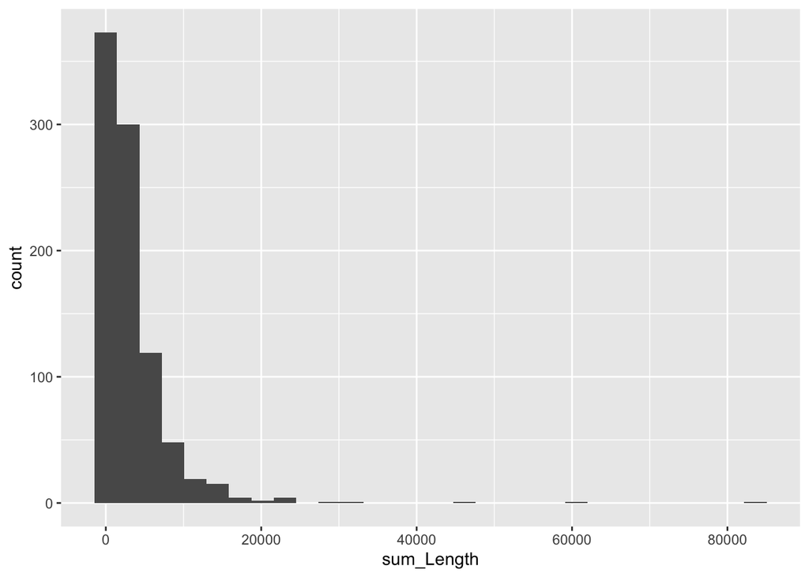

```r
bikeways_hist
```

### Displaying our results

```r
cont_summary <- tibble(
  Variable = c("Median Income ($)",
               "Transport (People)", "Median Age (Years)", "Bikeways (Feet)"),
  `Sample mean` = c(inc_t_test$estimate,
                    transport_t_test$estimate, age_t_test$estimate, bikeways_t_test$estimate * 1000),
  `Population mean (95% confidence) - low` =
    c(inc_t_test$conf.int[1],
      transport_t_test$conf.int[1], age_t_test$conf.int[1], bikeways_t_test$conf.int[1] * 1000),
  `Population mean (95% confidence) - high` =
    c(inc_t_test$conf.int[2],
      transport_t_test$conf.int[2], age_t_test$conf.int[2], bikeways_t_test$conf.int[2] * 1000),
  Median = c(inc_quartiles[3],
             transport_quartiles[3], age_quartiles[3], bikeways_quartiles[3] * 1000),
  `Interquartile range` = c(inc_quartiles[4] - inc_quartiles[2],
                            transport_quartiles[4] - transport_quartiles[2], age_quartiles[4] - age_quartiles[2], bikeways_quartiles[4] - bikeways_quartiles[2] * 1000),
  `Standard deviation` = c(inc_st_dev,
                          transport_st_dev, age_st_dev, bikeways_st_dev * 1000))

kable(cont_summary, digits = 0)
```

[output not shown]

## Categorical Variables

Our two categorical variables are % white and new residents, to measure gentrification and tenure.

```r
pct_white_maj <- t.test(acs_la_tracts_new$binary_white == "white")

pct_white_min <- t.test(acs_la_tracts_new$binary_white == "non_white")
```

```r
res_t_test <- t.test(acs_la_tracts_new2$percent_res_new)
```

### Formatted table for white population

```r
la_tract_summary <- tibble(`Race in Census Tracts` =
                              c("white_maj",
                                "white_min"),
                            `Sample proportion` =
                              c(pct_white_maj$estimate * 100,
                                pct_white_min$estimate *100),
                            `95-percent confidence - low` =
                              c(pct_white_maj$conf.int[1] * 100,
                                pct_white_min$conf.int[1] * 100),
                            `95-percent confidence - high` =
                              c(pct_white_maj$conf.int[2] * 100,
                                pct_white_min$conf.int[2] * 100))

kable(la_tract_summary, digits = 0)
```

| Race in Census Tracts | Sample proportion | 95-percent confidence - low | 95-percent confidence - high |
| --- | --- | --- | --- |
| white_maj | 49 | 46 | 52 |
| white_min | 51 | 48 | 54 |

### Formatted table for Tenure

```r
la_tract_tenure <- tibble(`Tenure in Census Tracts` =
                              c("New Residents"),
                            `Sample proportion` =
                              c(res_t_test$estimate * 100),
                            `95-percent confidence - low` =
                              c(res_t_test$conf.int[1] * 100),
                            `95-percent confidence - high` =
                              c(res_t_test$conf.int[2] * 100))

kable(la_tract_tenure)
```

| Tenure in Census Tracts | Sample proportion | 95-percent confidence - low | 95-percent confidence - high |
| --- | --- | --- | --- |
| New Residents | 0.9888507 | 0.8777612 | 1.09994 |

### Bar Chart % white

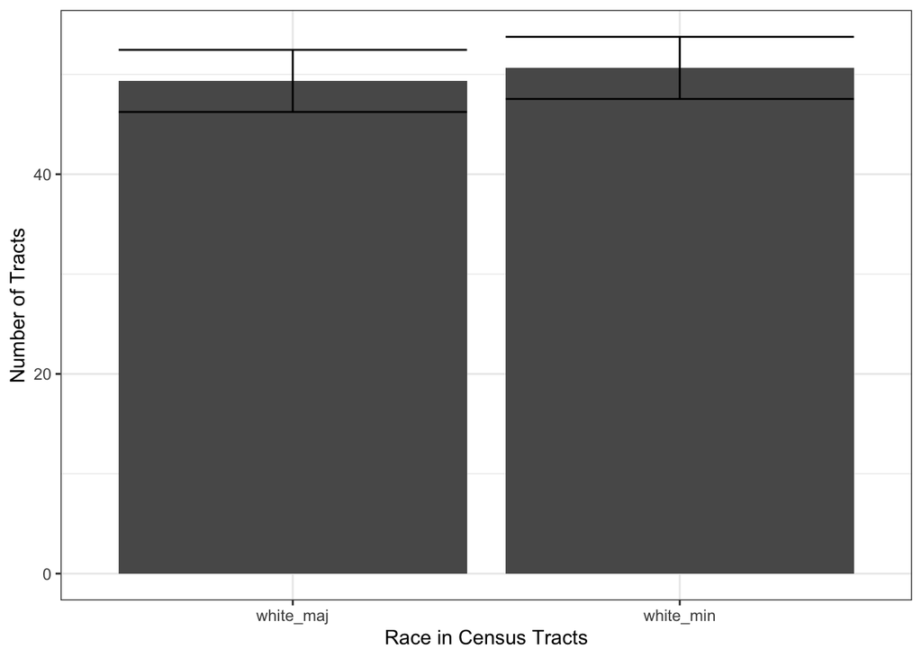

```r
ggplot(la_tract_summary) +
  geom_bar(aes(x = `Race in Census Tracts`,
               y = `Sample proportion`),
           stat = "identity") +
  geom_errorbar(aes(x = `Race in Census Tracts`,
               y = `Sample proportion`,
               ymin = `95-percent confidence - low`,
               ymax = `95-percent confidence - high`),
           stat = "identity") +
  scale_y_continuous(name = "Number of Tracts",
                     breaks = c(0, 20, 40, 60, 80),
                     labels = c("0", "20", "40", "60", "80")) +
  theme_bw()
```

# ASSIGNMENT 3 Bivariate Analysis

Running correlation test between continuous variables. Our bikeway length data was successfully clipped in ArcGIS Pro and we were then able to calculate the number of linear feet of bikeways per census tract (Thank you Jonathan), this created a final tally of 889 observations.

```r
cor.test(~ bikeways2$sum_Length + bikeways2$med_income_E)
```

```
##
##  Pearson's product-moment correlation
##
## data:  bikeways2$sum_Length and bikeways2$med_income_E
## t = 2.7435, df = 879, p-value = 0.006202
## alternative hypothesis: true correlation is not equal to 0
## 95 percent confidence interval:
##  0.02625443 0.15723626
## sample estimates:
##        cor
## 0.09214392
```

In running a bivariate analysis between these two continuous variables, our 95% confidence interval does not include zero, and all values are positive. The correlation coefficient leads us to conclude, with 95% confidence, that there is a weak positive relationship between length of bike lanes and median income per census tract.

Below we try the same method, but with a regression.

```r
bike_income_model <- lm(sum_Length ~ med_income_E, data = bikeways2)
summary(bike_income_model)
```

```
##
## Call:
## lm(formula = sum_Length ~ med_income_E, data = bikeways2)
##
## Residuals:
##    Min     1Q Median     3Q    Max
##  -4823  -2771  -1066   1128  43736
##
## Coefficients:
##                 Estimate  Std. Error t value           Pr(>|t|)
## (Intercept)  2371.882592  302.164044   7.850 0.0000000000000121 ***
## med_income_E    0.022567    0.008226   2.744             0.0062 **
## ---
## Signif. codes:  0 '***' 0.001 '**' 0.01 '*' 0.05 '.' 0.1 ' ' 1
##
## Residual standard error: 4108 on 879 degrees of freedom
##   (8 observations deleted due to missingness)
## Multiple R-squared:  0.008491,   Adjusted R-squared:  0.007363
## F-statistic: 7.527 on 1 and 879 DF,  p-value: 0.006202
```

Our p value here is the same as above and the R-Squared value of 0.008491 is the square value of the correlation coefficient 0.09214392.

## Density

We also choose to run an analysis of bikeway length and population density, to see if areas with more bike lanes have fewer people living in that census tract.

```r
cor.test(~ sum_Length + pop_E, data = bikeways2)
```

```
##
##  Pearson's product-moment correlation
##
## data:  sum_Length and pop_E
## t = -1.6693, df = 887, p-value = 0.0954
## alternative hypothesis: true correlation is not equal to 0
## 95 percent confidence interval:
##  -0.121268081  0.009824404
## sample estimates:
##         cor
## -0.05596303
```

Since the confidence interval includes zero, we cannot say with 95% certainty that bikeway length is associated with population density, however we still find this to be helpful to our research in acknowledging that bikelane length amount neither has a strong negative or positive correlation (with 95% certainty) with population density.

```r
dens_model <- lm(sum_Length ~ pop_E, data = bikeways2)
summary(dens_model)
```

```
##
## Call:
## lm(formula = sum_Length ~ pop_E, data = bikeways2)
##
## Residuals:
##    Min     1Q Median     3Q    Max
##  -4201  -2971  -1338   1046  79399
##
## Coefficients:
##              Estimate Std. Error t value         Pr(>|t|)
## (Intercept) 4201.1132   589.4363   7.127 0.00000000000212 ***
## pop_E         -0.2503     0.1499  -1.669           0.0954 .
## ---
## Signif. codes:  0 '***' 0.001 '**' 0.01 '*' 0.05 '.' 0.1 ' ' 1
##
## Residual standard error: 5291 on 887 degrees of freedom
## Multiple R-squared:  0.003132,   Adjusted R-squared:  0.002008
## F-statistic: 2.787 on 1 and 887 DF,  p-value: 0.0954
```

# Difference in the mean of categorical variables

We successfully clipped our bike lane length in ArcGIS and calculated the number of bike lanes in feet per census tract. we are presently curious in assessing if LA City tracks that are categorized as white majority have higher amounts of bike lanes than non-white majority tracts.

```r
t.test(sum_Length ~ binary_white, data = bikeways2)
```

```
##
##  Welch Two Sample t-test
##
## data:  sum_Length by binary_white
## t = -2.5909, df = 871.95, p-value = 0.009733
## alternative hypothesis: true difference in means between group non_white and group white is not equal to 0
## 95 percent confidence interval:
##  -1395.7137  -192.5488
## sample estimates:
## mean in group non_white     mean in group white
##                2790.904                3585.035
```

We can run the same result as a regression

```r
bike_race_model <- lm(sum_Length ~ binary_white, data = bikeways2)

summary(bike_race_model)
```

```
##
## Call:
## lm(formula = sum_Length ~ binary_white, data = bikeways2)
##
## Residuals:
##    Min     1Q Median     3Q    Max
##  -3585  -2791  -1247   1111  58996
##
## Coefficients:
##                   Estimate Std. Error t value             Pr(>|t|)
## (Intercept)         2790.9      213.6  13.068 < 0.0000000000000002 ***
## binary_whitewhite    794.1      306.0   2.595              0.00962 **
## ---
## Signif. codes:  0 '***' 0.001 '**' 0.01 '*' 0.05 '.' 0.1 ' ' 1
##
## Residual standard error: 4550 on 883 degrees of freedom
##   (4 observations deleted due to missingness)
## Multiple R-squared:  0.007568,   Adjusted R-squared:  0.006445
## F-statistic: 6.734 on 1 and 883 DF,  p-value: 0.009617
```

## Effect of race on bike lane length

We are running a linear regression to see if all white majority census tracts have more length of bike lanes than non-majority white census tracts.

```r
bikeways3 <- bikeways3 %>%
  mutate(binary_white = as.factor(binary_white)) %>%
  mutate(binary_white = relevel(binary_white, "non_white"))

binary_white_model <- lm(sum_Length ~ binary_white, data = bikeways3)

summary(binary_white_model)
```

```
##
## Call:
## lm(formula = sum_Length ~ binary_white, data = bikeways3)
##
## Residuals:
##    Min     1Q Median     3Q    Max
##  -3585  -2791  -1247   1111  58996
##
## Coefficients:
##                   Estimate Std. Error t value             Pr(>|t|)
## (Intercept)         2790.9      213.6  13.068 < 0.0000000000000002 ***
## binary_whitewhite    794.1      306.0   2.595              0.00962 **
## ---
## Signif. codes:  0 '***' 0.001 '**' 0.01 '*' 0.05 '.' 0.1 ' ' 1
##
## Residual standard error: 4550 on 883 degrees of freedom
##   (4 observations deleted due to missingness)
## Multiple R-squared:  0.007568,   Adjusted R-squared:  0.006445
## F-statistic: 6.734 on 1 and 883 DF,  p-value: 0.009617
```

The above regression is helpful in determining if all white majority bike lane lengths are greater than those of non white majority tracts, however this analysis would be most useful if we had greater than 2 categories in our categorical variable to compare to (ex. white majority of greater than 50%, white population of 30%, white population of 15%, etc.) This may be something we want to explore more in the future.

# Assignment 4: Multivariate Analysis

```r
full_model <- lm(sum_Length ~ percent_res_new + binary_white + pop_E + med_income_E + transport_E, bikeways3)

summary(full_model)
```

```
##
## Call:
## lm(formula = sum_Length ~ percent_res_new + binary_white + pop_E +
##     med_income_E + transport_E, data = bikeways3)
##
## Residuals:
##    Min     1Q Median     3Q    Max
##  -4778  -2460  -1096   1135  44357
##
## Coefficients:
##                       Estimate   Std. Error t value Pr(>|t|)
## (Intercept)        1407.539189   596.393514   2.360   0.0185 *
## percent_res_new   12197.233904  8498.844137   1.435   0.1516
## binary_whitewhite   718.358307   321.231389   2.236   0.0256 *
## pop_E                 0.225535     0.123690   1.823   0.0686 .
## med_income_E          0.014034     0.009626   1.458   0.1452
## transport_E          -4.066956     5.067740  -0.803   0.4225
## ---
## Signif. codes:  0 '***' 0.001 '**' 0.01 '*' 0.05 '.' 0.1 ' ' 1
##
## Residual standard error: 4090 on 875 degrees of freedom
##   (8 observations deleted due to missingness)
## Multiple R-squared:  0.02138,    Adjusted R-squared:  0.01578
## F-statistic: 3.823 on 5 and 875 DF,  p-value: 0.001972
```

In our bivariate regression with binary_whitewhite (white majority census tracts) and sum_Length (feet of bike lane per census tract), we found, on average, that white majority census tracts in Los Angeles have 794.1 more feet of bike lane than non-white majority census tracts. This finding was significant at the 99% confidence level. With a p-value of 0.00962, the likelihood of getting the same result by chance was 0.962%

However, in our multivariate regression with tenure, population, median income, and transport mode (bicycle), the coefficient for binary_whitewhite dropped to 718.4 feet. In other words, controlling for tenure, population, median income, and transport mode (bicycle), we still found that white majority census tracts were positively correlated with the number of feet of bike lane per census tract, but with a slightly smaller coefficient and at a lower confidence level of 95%. With a p-value of 0.0256, the likelihood of getting the same result by chance was 2.56%. None of the other variables in our regression met the 95% confidence level, which is the standard for the social sciences.

In our multivariate regression, we also noted a small, positive relationship between sum_Length and population of 0.225535 feet. That is to say, each additional person is associated with 0.225535 more feet of bike lane per census tract. This finding was significant at the 90% confidence level. With a p-value of 0.0686, the likelihood of getting the same result by chance was 6.86%.

Overall, based on an r-squared value of 0.02138, our model explains approximately 2.14% of the variation in bike lane length per census tract in Los Angeles.

# Assignment 5: Transformations

Prior to starting Assignment 5, we wanted to tidy up our previous data and add new variables to explore. We also confirmed that we were using a more restrictive definition of bikeway infrastructure, whiches excluding sharrows and other infrastructure that is not a bike lane separated from vehicular traffic.

## Rerun multivariate analysis

```r
full_model2 <- lm(sum_Length ~ percent_res_new + binary_white + pop_density + med_income_E + percent_bike, bikeways3)

summary(full_model2)
```

```
##
## Call:
## lm(formula = sum_Length ~ percent_res_new + binary_white + pop_density +
##     med_income_E + percent_bike, data = bikeways3)
##
## Residuals:
##    Min     1Q Median     3Q    Max
##  -4727  -2428   -842   1295  42852
##
## Coefficients:
##                       Estimate   Std. Error t value             Pr(>|t|)
## (Intercept)        4662.961044   422.128577  11.046 < 0.0000000000000002 ***
## percent_res_new   15206.923287  8186.512150   1.858               0.0636 .
## binary_whitewhite   153.617258   317.906509   0.483               0.6291
## pop_density          -0.085861     0.010606  -8.095  0.00000000000000191 ***
## med_income_E         -0.008661     0.009564  -0.906               0.3654
## percent_bike       4912.191344 17454.085867   0.281               0.7784
## ---
## Signif. codes:  0 '***' 0.001 '**' 0.01 '*' 0.05 '.' 0.1 ' ' 1
##
## Residual standard error: 3951 on 875 degrees of freedom
##   (8 observations deleted due to missingness)
## Multiple R-squared:  0.08674,    Adjusted R-squared:  0.08152
## F-statistic: 16.62 on 5 and 875 DF,  p-value: 0.000000000000001056
```

```r
bikeways3$log_pop_density <- log(bikeways3$pop_density)
```

```r
full_model3 <- lm(sum_Length ~ percent_res_new + binary_white + log_pop_density + med_income_E + percent_bike, bikeways3)

summary(full_model3)
```

```
##
## Call:
## lm(formula = sum_Length ~ percent_res_new + binary_white + log_pop_density +
##     med_income_E + percent_bike, data = bikeways3)
##
## Residuals:
##    Min     1Q Median     3Q    Max
## -16160  -2220   -608   1352  33814
##
## Coefficients:
##                       Estimate   Std. Error t value             Pr(>|t|)
## (Intercept)       24642.751882  1736.321116  14.193 < 0.0000000000000002 ***
## percent_res_new   14521.545671  7765.526195   1.870               0.0618 .
## binary_whitewhite    14.670277   299.221835   0.049               0.9609
## log_pop_density   -2169.775581   166.466661 -13.034 < 0.0000000000000002 ***
## med_income_E         -0.039260     0.009589  -4.094            0.0000462 ***
## percent_bike      26057.003336 16681.992739   1.562               0.1187
## ---
## Signif. codes:  0 '***' 0.001 '**' 0.01 '*' 0.05 '.' 0.1 ' ' 1
##
## Residual standard error: 3749 on 875 degrees of freedom
##   (8 observations deleted due to missingness)
## Multiple R-squared:  0.1779, Adjusted R-squared:  0.1733
## F-statistic: 37.88 on 5 and 875 DF,  p-value: < 0.00000000000000022
```

We used the below code to transform the above data into a cleaner table.

```r
coeff_names_scaled <- c("Constant" = "(Intercept)",
                 "New residents (%)" = "percent_res_new",
                 "Majority white (binary)" = "binary_whitewhite",
                 "Log population density (people/sqmi)" = "log_pop_density",
                 "Median income ($)" = "med_income_E",
                 "Bike commuters (%)" = "percent_bike")

export_summs(full_model2, full_model3,
             error_format = "(p = {p.value})",
             error_pos = "same",
             model.names = c("Initial",
                             "Logged"),
             coefs = coeff_names_scaled)
```

|  | Initial | Logged |
| --- | --- | --- |
| Constant | 4662.96 *** (p = 0.00) | 24642.75 *** (p = 0.00) |
| New residents (%) | 15206.92 (p = 0.06) | 14521.55 (p = 0.06) |
| Majority white (binary) | 153.62 (p = 0.63) | 14.67 (p = 0.96) |
| Log population density (people/sqmi) |  | -2169.78 *** (p = 0.00) |
| Median income ($) | -0.01 (p = 0.37) | -0.04 *** (p = 0.00) |
| Bike commuters (%) | 4912.19 (p = 0.78) | 26057.00 (p = 0.12) |
| N | 881 | 881 |
| R2 | 0.09 | 0.18 |
| *** p < 0.001; ** p < 0.01; * p < 0.05. |  |  |

After we log transformed population density and re-ran the regression, log_pop_density retained its significance and med_income_E also became statistically significant. The R-squared value tells how much of the variation in the dependent variable is due to the other independent variables. Our R-squared is .1779 for the log transformation, which is up from .086. This means that our model now explains 17.79% of the variation in the dependent variable (rounded to 18% in the cleaner table).

#References

- Blame it on the bike: Does cycling contribute to a city’s gentrification? | Cities | The Guardian. (n.d.). Retrieved October 25, 2021, from https://www.theguardian.com/cities/2016/oct/05/blame-bike-cycling-contribute-city-gentrification
- Davis, J. (2021, July 15). The double-edged sword of upzoning. Brookings. https://www.brookings.edu/blog/how-we-rise/2021/07/15/the-double-edged-sword-of-upzoning/
- Ferenchak, N. N., & Marshall, W. E. (2021). Bicycling facility inequalities and the causality dilemma with socioeconomic/sociodemographic change. Transportation Research Part D: Transport and Environment, 97, 102920. https://doi.org/10.1016/j.trd.2021.102920
- Flanagan, E., Lachapelle, U., & El-Geneidy, A. (2016). Riding tandem: Does cycling infrastructure investment mirror gentrification and privilege in Portland, OR and Chicago, IL? Research in Transportation Economics, 60, 14–24. https://doi.org/10.1016/j.retrec.2016.07.027
- LADOT Walk & Bike Count. (n.d.). LADOT. Retrieved October 25, 2021, from https://ladot.lacity.org/walkbikecount
- Radio, S. C. P. (700, 00:44). Watch a decade of growth in LA’s bike infrastructure. Southern California Public Radio. https://archive.kpcc.org/news/2015/04/10/50849/watch-a-decade-of-growth-in-la-s-bike-infrastructu/
- What the Latest Census Data Says About L.A. City Bicycle Commuting. (2014, September 23). Streetsblog Los Angeles. https://la.streetsblog.org/2014/09/23/what-the-latest-census-data-says-about-l-a-city-bicycle-commuting/

# Thank you

Group 7 would like to thank Prof. Voulgaris and TAs for reviewing our work, and look forward to another semester.